# Class 7 - APIs & Census data in R

Demo for using APIs, Census data

# Writing API Calls to NYC Open Data

*Adapted from Sam Rabiyah’s demo last year*

When downloading data from [NYC Open Data](https://opendata.cityofnewyork.us/), you can use a special set of commands to filter and manipulate the data before downloading it to your local computer. These commands, unlike ones you’d write in an R script, are actually written **in the URL itself**. This kind of command is called an “API Call”— API stands for “Application programming interface” and is just a special system and language for users to communicate with the NYC Open Data servers. API Calls to NYC Open Data use a special syntax, very similar to a popular language called SQL or Structured Query Language.

Using API Calls is particularly useful when you’re dealing with a **huge dataset** that would otherwise be a hassle to download in full. For this example, we’re going to use the [HPD’s Housing Maintinance Code Violations](https://data.cityofnewyork.us/Housing-Development/Housing-Maintenance-Code-Violations/wvxf-dwi5) dataset on NYC Open Data, which has ~7 million rows.

## Step 1: Grabbing the “API Endpoint”

Let’s first grab the beginning part of the URL that we’re going to use to write our API Call. This is called the “API Endpoint” and can be found by clicking the “API” tab on the NYC Open Data page for the dataset you’re working with.

Before copying the URL, make sure you set the data format toggle from “JSON” to “CSV”, as that is the format we’re going to want our data in.

For our example, our endpoint looks like this:

```
https://data.cityofnewyork.us/resource/wvxf-dwi5.csv
```

## Step 2: Writing up your API Call

Copy the API Endpoint into a text editor (I prefer [Sublime Text](https://www.sublimetext.com/) or [Visual Studio Code](https://code.visualstudio.com/)— others like Word or Pages have a tendency to “auto-correct” certain letters and syntax which may mess you up).

Now, to initiate our query, we are going to add `?$query=` to the end of our URL:

```
https://data.cityofnewyork.us/resource/wvxf-dwi5.csv?$query=
```

## Step 3: Adding your Query

At the end our URL, we can now add some special code to filter the violations data for our download.

To do this, we’re going to want to first take a look at the [API Documentation](https://dev.socrata.com/foundry/data.cityofnewyork.us/wvxf-dwi5) for our dataset of choice, which can be found by clicking on the “API” tab again on the dataset’s Open Data page and clicking the “API Docs” button. Specifically, this documentation gives us a run down of all of the columns in the data and how we can reference them by name in our API call.

**`SELECT *`** – this selects all columns of the data

**`WHERE inspectiondate>='2021-06-01T00:00:01.000' AND inspectiondate<'2021-09-01T00:00:01.000' AND class='C'`** – this filters only rows where the `inspectiondate` value is between June 1st and Aug 31st, and the class of the violation is `'C'`. The `AND` operator here allows us to include multiple filtering conditions at once, and could even include conditions on other columns. Note the special format that the dates come in… we were able to spot this by looking at the [Documentation](https://dev.socrata.com/foundry/data.cityofnewyork.us/wvxf-dwi5).

**`LIMIT 100000`** — this sets the maximum number of downloadable rows to 100,000. It’s good practice to set a limit here so we don’t accidentially try downloading millions of rows at once. **Note: if you don’t specify, the default limit is just 1,000 rows!**

You can find more information on the types of queries you can write on the [Socrata Developers Portal](https://dev.socrata.com/docs/queries/query.html) (Socrata is the special “flavor” of API that NYC Open Data uses).

## Step 4: Running our API Call

We add the above pieces in that order to our URL:

`https://data.cityofnewyork.us/resource/wvxf-dwi5.csv?$query=SELECT * WHERE inspectiondate>='2021-06-01T00:00:01.000' AND inspectiondate<'2021-09-01T00:00:01.000' AND class='C' LIMIT 100000`

Now, you can copy this full url into your browser and press ENTER— your special download should begin!

## Importing your data directly into R Studio

Once you have your data downloaded via API Call, you can feel free to import it into your R project like any other CSV. If you want to use the URL you created to import it directly, you can do that as well:

```r
library(tidyverse)
library(fs)

# R doesn't like weird characters like spaces and carats, so we need the `URLencode` function here to encode those symbols properly

url_hpd_viol <- URLencode("https://data.cityofnewyork.us/resource/wvxf-dwi5.csv?$query=SELECT * WHERE inspectiondate>='2021-06-01T00:00:01.000' AND inspectiondate<'2021-09-01T00:00:01.000' AND class='C' LIMIT 100000")


# Now, we can use our formatted url inside our `read_csv` function

summer_hpd_viols <- read_csv(url_hpd_viol)
```

## Note: Always check the size of your output

Sometimes, the limit on your API Call may make your data export smaller than your desired outcome, and you won’t necessarily be notified. Therefore, it is always very important to **check the number of rows** of your data from your API Call before proceeding with analysis— if the number of rows matches the exact number of your limit (or is 1000, the default limit), it’s very likely that your data got cut off and you don’t have the complete set of data that you wanted.

The below example illustrates this problem and shows how to diagnose. For the example, imagine that we didn’t include a `LIMIT` clause in our API Call query:

`https://data.cityofnewyork.us/resource/wvxf-dwi5.csv?$query=SELECT * WHERE inspectiondate>='2021-06-01T00:00:01.000' AND inspectiondate<'2021-09-01T00:00:01.000'`

```r
url_viol_no_limit = URLencode("https://data.cityofnewyork.us/resource/wvxf-dwi5.csv?$query=SELECT * WHERE inspectiondate>='2021-06-01T00:00:01.000' AND inspectiondate<'2021-09-01T00:00:01.000'")

summer_violations_cut_off <- read_csv(url_viol_no_limit)

# Using the head() function won't actually reveal the cut-off problem:
head(summer_violations_cut_off)
```

```
# A tibble: 6 × 41
  violationid buildingid registrationid boroid boro     housenumber
        <dbl>      <dbl>          <dbl>  <dbl> <chr>    <chr>
1    14369092     138864         354171      3 BROOKLYN 377
2    14367984     102645         216347      2 BRONX    810
3    14368258     382460         360973      3 BROOKLYN 231
4    14368271     382460         360973      3 BROOKLYN 231
5    14368325     216471         335844      3 BROOKLYN 110
6    14368306     382460         360973      3 BROOKLYN 231
# … with 35 more variables: lowhousenumber <chr>,
#   highhousenumber <chr>, streetname <chr>, streetcode <dbl>,
#   zip <dbl>, …
```

By looking at the head of your dataset, things appear to be fine. However, let’s use the `nrow()` function to get a sense of how many rows we have:

```r
nrow(summer_violations_cut_off)
```

```
[1] 1000
```

Given that our data output is 1,000 rows, which is exactly the default limit for API Calls to NYC Open Data, it’s very likely that our data got cut off and there are more rows within our filtering conditions that we want.

# Census/ACS data with `tidycensus`

There are many other types of data access APIs out there, and some of them are slightly more complex with the options that are avilable. Luckily, there are often custom R packages designed to help simplify your interactions with the API so you can provide arguments to R functions and the function will build out the URL request for you.

The [`tidycensus`](https://walker-data.com/tidycensus/) package uses the Census Bureau’s APIs to download Decennial Census and ACS summary file estaimtes. As the name implies, the package fits in with the tidyverse collection of packages.

While the Census API is free to use, they require you to sign up for an API Key to get access. This is easy to do, all you need to provide is an email and there are instructions for doing this on the help package for this function: `?census_api_key`

```r
library(tidycensus)

# you're welcome to use this API code for today's demo
census_api_key("c32dfbf7d25fe9558fd11bf021780457970f96ff")
```

Tidycensus includes decennial census and ACS data, but today we’ll stick with just ACS using `get_acs()`. There are many variables and they need to be specified using codes. We can explore these using `load_variables()`

```r
acs_vars <- load_variables(2019, "acs5", cache = TRUE)
acs_vars
```

```
# A tibble: 27,040 × 3
   name       label                                    concept
   <chr>      <chr>                                    <chr>
 1 B01001_001 Estimate!!Total:                         SEX BY AGE
 2 B01001_002 Estimate!!Total:!!Male:                  SEX BY AGE
 3 B01001_003 Estimate!!Total:!!Male:!!Under 5 years   SEX BY AGE
 4 B01001_004 Estimate!!Total:!!Male:!!5 to 9 years    SEX BY AGE
 5 B01001_005 Estimate!!Total:!!Male:!!10 to 14 years  SEX BY AGE
 6 B01001_006 Estimate!!Total:!!Male:!!15 to 17 years  SEX BY AGE
 7 B01001_007 Estimate!!Total:!!Male:!!18 and 19 years SEX BY AGE
 8 B01001_008 Estimate!!Total:!!Male:!!20 years        SEX BY AGE
 9 B01001_009 Estimate!!Total:!!Male:!!21 years        SEX BY AGE
10 B01001_010 Estimate!!Total:!!Male:!!22 to 24 years  SEX BY AGE
# … with 27,030 more rows
```

The list can be a bit overwhelming, so to make it easier to first find the table use RStudio’s data viewer and the column filter option to filter to just the first row of each table `"_001"`

The main function to extract the data is a bit complicated, you should pull up the help page (`?get_acs`) and walk through the arguments as you write it out.

- `geography`: the level of geography we want for our data, in this case census tract. ([Full list of all available geography levels](https://walker-data.com/tidycensus/articles/basic-usage.html#geography-in-tidycensus))
- `state`: if the requested geography nests within states, you can limit to one or more states
- county: if the requested geography nests within counties, you can limit to one or more counties
- `variables`: this can either be a simple vector of variable codes, or a named vector of variable codes where the names replace the codes in the column names
- `survey`: the ACS releases 1-, 3-, and 5-year estimates. (Tracts are only available with 5-year data)
- `year`: this is the latest year of the range. So 2018 with “acs5” means 2014-2018
- `output`: this can either be “tidy” (default) or wide. For mapping “wide” makes since - where each variable is it’s own column
- `geometry`: whether to include geometries (shapes) with the data

In this demo we’ll just be downloading the estimates, but another version of the demo that incorporates the geometries for mapping will be posted as well.

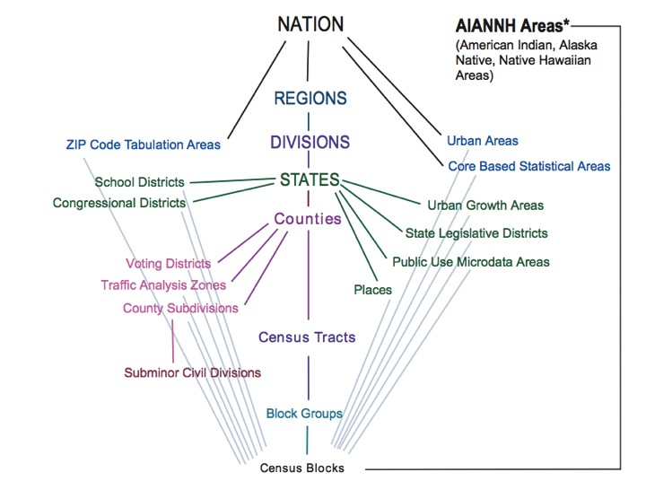

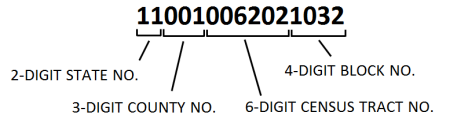

```r
boro_acs_raw <- get_acs(
  geography = "county",
  state = "NY",
  county = c("005", "047", "061", "081", "085"), # NYC counties/boroughs
  variables = c(
    "gross_rent_med" = "B25064_001", # median gross rent
    "hh_inc_med" = "B19013_001", # median household income
    "rent_burden_med" = "B25071_001", # median rent burden
    "pov_pct" = "C17002_001", # poverty rate
    "hh_size_avg" = "B25010_001", # average household size
    "occ_units" = "B25003_001", # total occupied units
    "occ_renter_units" = "B25003_003" # renter occupied units
  ),
  survey = "acs1", # with county we can use 1-year
  year = 2019,
  output = "wide",
  geometry = FALSE
)

boro_acs_raw
```

```
# A tibble: 5 × 16
  GEOID NAME   gross_rent_medE gross_rent_medM hh_inc_medE hh_inc_medM
  <chr> <chr>            <dbl>           <dbl>       <dbl>       <dbl>
1 36005 Bronx…            1231              19       41432        1090
2 36047 Kings…            1483              16       66937        1343
3 36085 Richm…            1299              55       89821        5711
4 36081 Queen…            1641              19       73696        1832
5 36061 New Y…            1753              42       93651        3322
# … with 10 more variables: rent_burden_medE <dbl>,
#   rent_burden_medM <dbl>, pov_pctE <dbl>, pov_pctM <dbl>,
#   hh_size_avgE <dbl>, …
```

```r
boro_acs_clean <- boro_acs_raw %>%
  mutate(
    county = str_sub(GEOID, 3, 5),
    boro = recode(county, "005" = "Bronx", "047" = "Brooklyn",
                  "061" = "Manhattan", "081" = "Queens",
                  "085" = "Staten Island"),
    renter_pctE = occ_renter_unitsE / na_if(occ_unitsE, 0),
    renter_pctM = moe_ratio(occ_renter_unitsE, na_if(occ_unitsE, 0),
                            occ_renter_unitsM, occ_unitsM),
  )

boro_acs_clean
```

```
# A tibble: 5 × 20
  GEOID NAME   gross_rent_medE gross_rent_medM hh_inc_medE hh_inc_medM
  <chr> <chr>            <dbl>           <dbl>       <dbl>       <dbl>
1 36005 Bronx…            1231              19       41432        1090
2 36047 Kings…            1483              16       66937        1343
3 36085 Richm…            1299              55       89821        5711
4 36081 Queen…            1641              19       73696        1832
5 36061 New Y…            1753              42       93651        3322
# … with 14 more variables: rent_burden_medE <dbl>,
#   rent_burden_medM <dbl>, pov_pctE <dbl>, pov_pctM <dbl>,
#   hh_size_avgE <dbl>, …
```

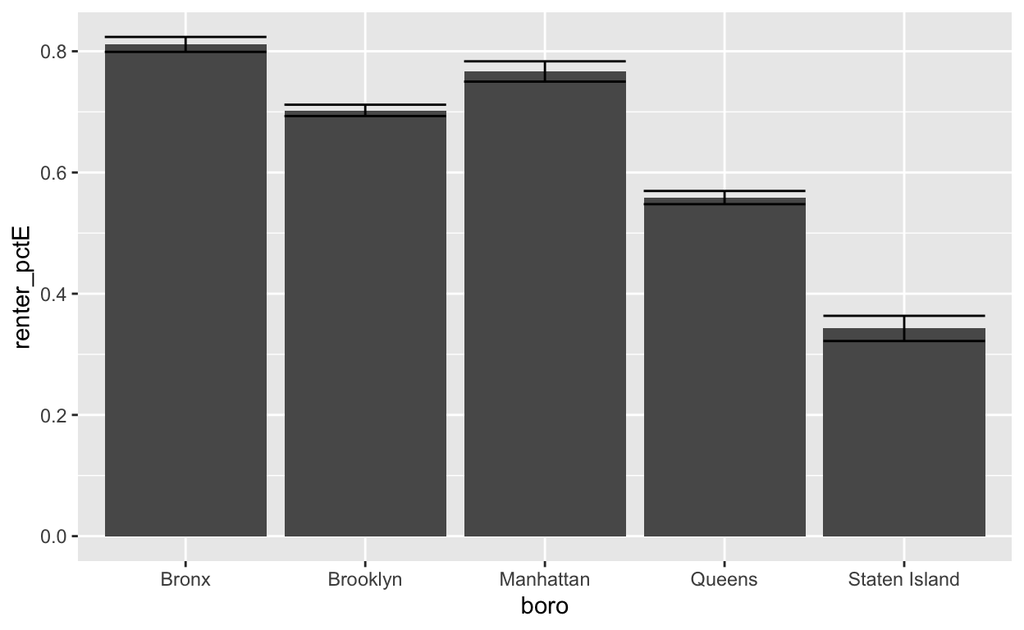

```r
ggplot(boro_acs_clean) +
  aes(
    x = boro,
    y = renter_pctE,
    ymin = renter_pctE - renter_pctM,
    ymax = renter_pctE + renter_pctM
  ) +
  geom_col() +
  geom_errorbar()
```

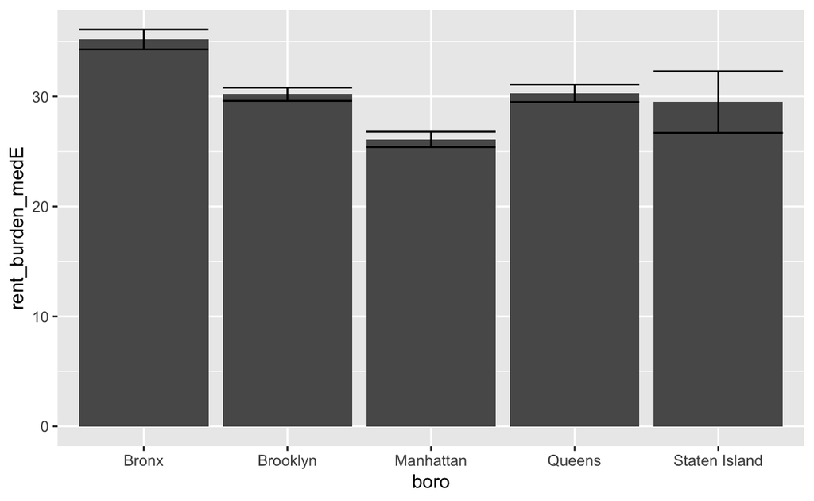

```r
ggplot(boro_acs_clean) +
  aes(
    x = boro,
    y = rent_burden_medE,
    ymin = rent_burden_medE - rent_burden_medM,
    ymax = rent_burden_medE + rent_burden_medM
  ) +
  geom_col() +
  geom_errorbar()
```